# Soybean Export Forecast with R

Felipe Tufaile, Vinicius de Camargo, Helena Funari, Rodrigo Zamengo

2022-11-07

### Loading libraries

```r
## Set working directory
setwd("~/Insper/Commodity_Export_Forecast")

library(dplyr)
library(tidyverse)
library(ggthemes)
library(fpp3)
library(forecast)
library(gridExtra)
library(ggpubr)
library(tseries)
```

### Defining Functions

The following codes aims to define some function that will help plotting graphs and analyzing the time series through this study.

```r
## Creating function for adding time series to ggplots
add_serie <- function(data, xdata, ydata, name, color, text_position, labels) {

  list(geom_line(data=data, aes(x=.data[[xdata]], y=.data[[ydata]], color=name), linetype="solid", alpha=0.8),
       geom_text(data=data, aes(x=.data[[xdata]], y=.data[[ydata]], label=.data[[labels]]),
                 colour = color,
                 size=2.5,
                 vjust=ifelse(text_position=="Above", -1, 2), hjust=0.5))
}

## Defining custom x-labels for time series plot without lag
time_series_xlabels <- function(){
  scale_x_date(breaks=seq(from=as.Date("1997-01-01"), to=as.Date("2022-01-01"), by = "12 month"),
               date_label = "%b\n%y", expand=expansion(mult = c(0.02, 0.02)))
}

## Defining custom themes
time_series_theme <- function(){
  theme_hc() +
  theme(plot.background = element_rect(fill = "white"),
        panel.background = element_rect(fill = "white"),
        panel.grid.major.y = element_line(colour = '#E6E7E8'),
        panel.grid.minor.y = element_line(colour = '#E6E7E8'),
        panel.grid.major.x = element_blank(),
        panel.grid.minor.x = element_blank(),
        axis.line.y = element_line(colour = '#000000'),
        axis.line.x = element_line(colour = '#000000'),
        axis.text.y = element_text(colour = '#000000', size=8),
        axis.ticks.y = element_line(colour = '#000000'),
        axis.title.y = element_text(colour = '#000000', size=8),
        legend.position = "bottom",
        plot.title = element_text(colour = "#000000", size=14),
        plot.subtitle = element_text(colour = '#585858', size=12),
        text = element_text(colour = '#585858', size=9),
        axis.text = element_text(colour = '#585858', size=8))
  }
```

### Data Loading

The database used in this study was taken from the open data platform of the ministry of agriculture. The platform has import and export information for various agribusiness products aggregated by month, year, country, state, product, among other groupings. The Information is available at the following link: https://indicadores.agricultura.gov.br/agrostat/index.htm. As mentioned in the beggining of this study, the dataset will be filtered in order to consider only soy bean volume exported from the Midwest of Brazil.

```r
# Reading export dataset
export <- read_csv("export_database.csv")

# Selecting soy bean production in midwest
midwest_soybean <- export %>%
  filter(produto == 'COMPLEXO SOJA' & regiao == 'CENTRO-OESTE' & ref_ano >= 2000 & ref_ano <= 2021) %>%
  group_by(ref_date_fmd) %>%
  summarize(vl_mm_ton = sum(massa_exportada_kg)/10^9)
```

### Plotting time-series

The following chart shows the mass (millions of ton) of soy bean exported from January of 2000 to December of 2021. In order to account only for complete years, the year of 2022 was left out of this plot, but will be used later on this document. Looking at the plot, it can be noticed that the time series seems to have a well defined seasonal pattern, but with increasing variance along the years. That is, the series denotes a heteroskedastic behavior. Given this fact, a Box Cox transformation could help make the data more ‘normally’ distributed and thus help stabilize its variance. With this transformation, forecasting can be substantially simpler. For that reason it will also be studied the Box-Cox transformed time series.

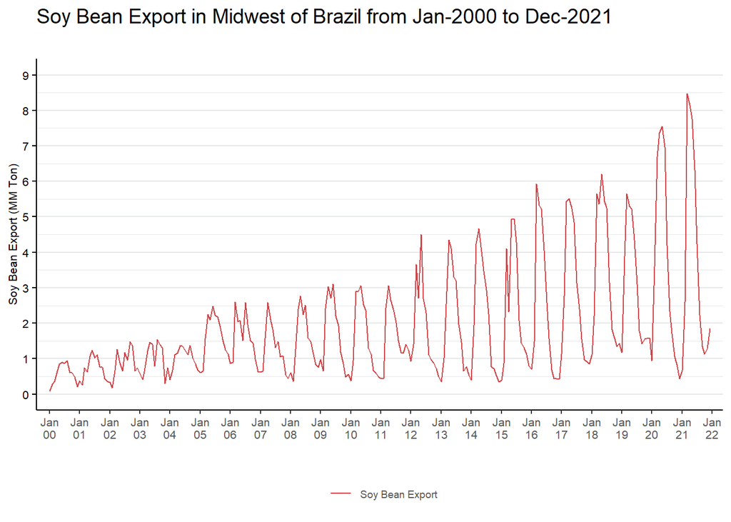

```r
## Plotting
plot <- ggplot() +
  add_serie(data=midwest_soybean %>% mutate(labels = ""),
            xdata="ref_date_fmd",
            ydata="vl_mm_ton",
            name='Soy Bean Export',
            color="#C4161C",
            text_position="Above",
            labels="labels") +
  scale_color_manual(name="", breaks=c('Soy Bean Export'), values=c('#C4161C')) +
  time_series_xlabels() +
  scale_y_continuous(limits=c(0, 9), breaks=seq(0, 9, 1), minor_breaks=seq(0, 9, 0.5)) +
  labs(x = "",
       y = "Soy Bean Export (MM Ton)",
       title="Soy Bean Export in Midwest of Brazil from Jan-2000 to Dec-2021",
       subtitle="") +
  time_series_theme()

plot
```

### Applying a boxcox transformation on the time-series

A Box-Cox transformation is a power transform function that is used to stabilize variance and make the data more “normally” distributed, which may improve the performance in forecasting for some time-series models. The one-parameter Box-Cox transformation is defined as:

$$\begin{align*}
y_{i}^{(\lambda)} = \frac{y_{i}^{(\lambda)}-1}{\lambda} \text{ if } \lambda \ne 0 \\
y_{i}^{(\lambda)} = \ln(y_{i}) \text{ if } \lambda = 0
\end{align*}$$

Applying the transformation on the original time-series yields:

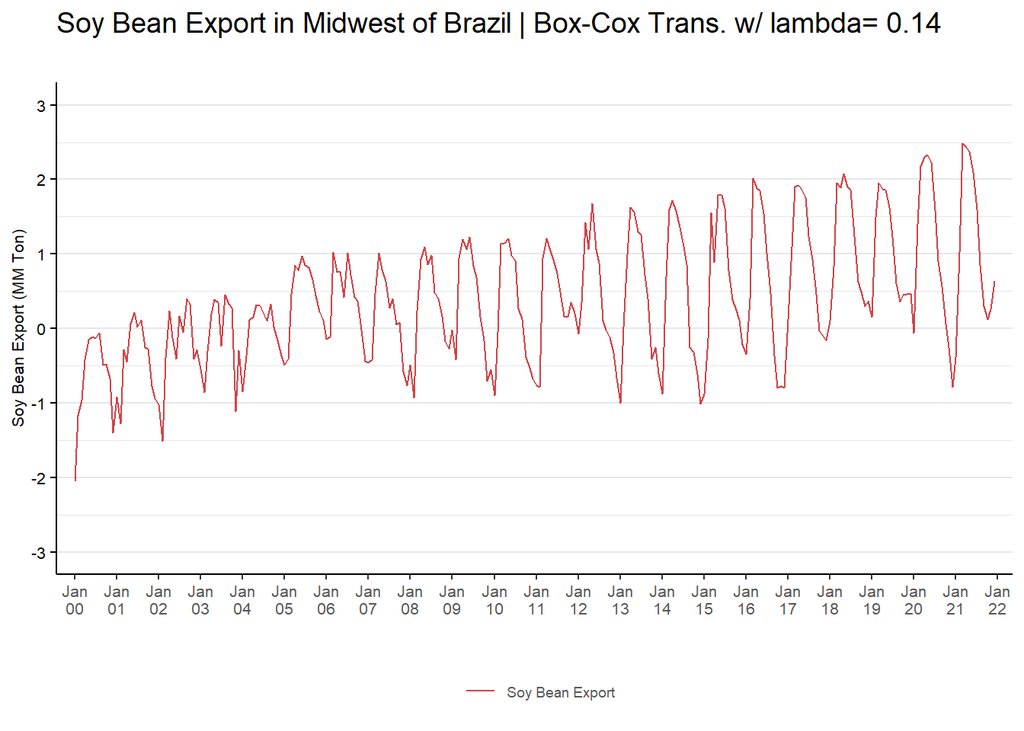

```r
## Calculating boxcox transformation on vl_mm_ton
boxcox_transform <- BoxCox(midwest_soybean$vl_mm_ton, lambda = "auto")

## Creating a new tibble with the transformed vl_mm_ton value
midwest_soybean_boxcox <- tibble(ref_date_fmd = midwest_soybean$ref_date_fmd,
                                 vl_mm_ton_boxcox = c(boxcox_transform))

## Getting calculated lambda
boxcox_lambda <-attributes(boxcox_transform)$lambda

## Plotting
plot <- ggplot() +
  add_serie(data=midwest_soybean_boxcox %>% mutate(labels = ""),
            xdata="ref_date_fmd",
            ydata="vl_mm_ton_boxcox",
            name="Soy Bean Export",
            color="#C4161C",
            text_position="Above",
            labels="labels") +
  scale_color_manual(name="", breaks=c('Soy Bean Export'), values=c('#C4161C')) +
  time_series_xlabels() +
  scale_y_continuous(limits=c(-3, 3), breaks=seq(-3, 3, 1), minor_breaks=seq(-3, 3, 0.5)) +
  labs(x = "",
       y = "Soy Bean Export (MM Ton)",
       title=paste('Soy Bean Export in Midwest of Brazil | Box-Cox Trans. w/ lambda=', round(boxcox_lambda,2)),
       subtitle="") +
  time_series_theme()

plot
```

It can be seem that the transformation helped to reduce the change in variance over time, although it seems that there is still a difference in the variance of recent years and older years. In order to validate if the transformation in fact helped to give a more normal-like distribution, the following chart shows a qq plot of the original and Box-Cox transformed series. It is evident that the transformed series is more adherent to the straight line in the chart, meaning the transformation has improved normality.

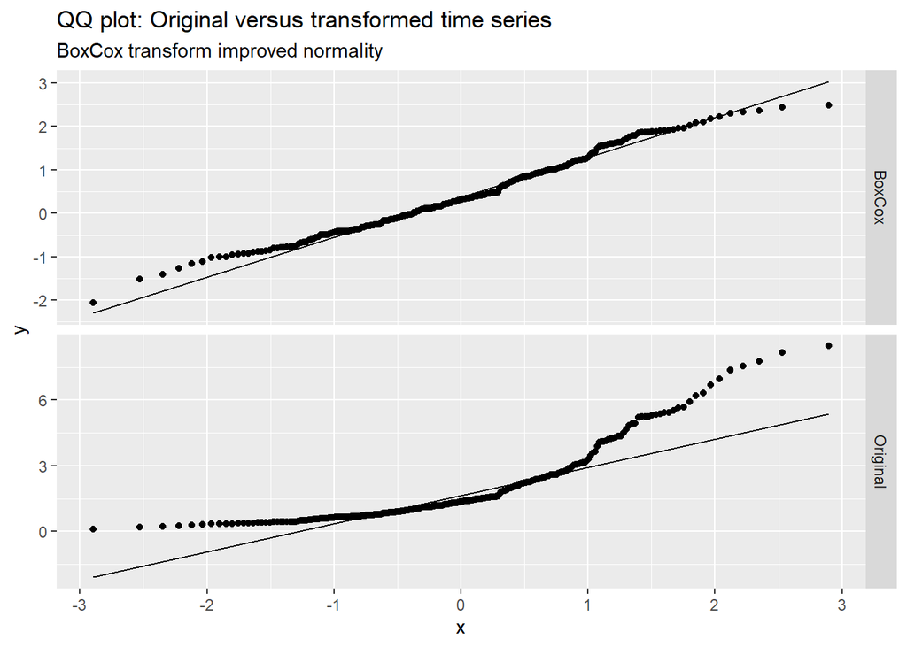

```r
df_hist = rbind(tibble(vl_mm_ton = as.double(midwest_soybean$vl_mm_ton), type = "Original"),
                tibble(vl_mm_ton = as.double(midwest_soybean_boxcox$vl_mm_ton_boxcox), type = "BoxCox"))
ggplot(df_hist, aes(sample = vl_mm_ton)) +
geom_qq() +
geom_qq_line() +
facet_grid(type ~ ., scales = "free_y") +
ggtitle("QQ plot: Original versus transformed time series", "BoxCox transform improved normality")
```

### Time Series Analysis and ACF / PACF plots

Analyzing the time series in the above figures it seems that both time series, original and transformed, have a stochastic trend since there seems to be some randomness building up over time. In order to confirm that observation it will be applied a **ADF** (Augmented Dicker-Fuller) test to check if there is unit-roots present in the series.

**ADF test on original time series**

```r
tseries::adf.test(midwest_soybean$vl_mm_ton,
                  alternative = c("stationary", "explosive"),
                  k = trunc((length(midwest_soybean$vl_mm_ton)-1)^(1/3)))
```

```
##
##  Augmented Dickey-Fuller Test
##
## data:  midwest_soybean$vl_mm_ton
## Dickey-Fuller = -11.123, Lag order = 6, p-value = 0.01
## alternative hypothesis: stationary
```

**ADF test on transformed time series**

```r
tseries::adf.test(midwest_soybean_boxcox$vl_mm_ton_boxcox,
                  alternative = c("stationary", "explosive"),
                  k = trunc((length(midwest_soybean_boxcox$vl_mm_ton_boxcox)-1)^(1/3)))
```

```
##
##  Augmented Dickey-Fuller Test
##
## data:  midwest_soybean_boxcox$vl_mm_ton_boxcox
## Dickey-Fuller = -9.5935, Lag order = 6, p-value = 0.01
## alternative hypothesis: stationary
```

The null hypothesis of the **ADF** assumes that there is an unit root in the time series (therefore the series is non-stationary), whereas the alternate hypothesis, as configured in the function above, assumes that the series are stationary. Since the p-values obtained for both tests are low (less than 0.05) the null hypothesis is rejected indicating that the series, original and transformed, are stationary. However, as mentioned by Robert Hyndman in his book, different unit root tests are available, which are based on different assumptions and may lead to conflicting answers (Hyndman, 2021). In the book, Hyndman suggests the Kwiatkowski-Phillips-Schmidt-Shin (**KPSS**) test (Kwiatkowski et al., 1992) as an alternative. As indicated in the reference mentioned, the **KPSS** test assumes that the data is stationary as the null hypothesis. Therefore, small p-values suggest that the data has an unit root and that differencing is required. In addition, as this analysis deals with a time series of an agricultural crop, it is expected that there is a well-defined seasonality of 12 months. The **fabletools** package also checks for the presence of seasonal unit roots, as it will be studied in the sequence. Applying the **KPSS** looking for seasonal unit roots yields:

**KPSS test on original time series**

```r
## Building time series object on exporting data
midwest_soybean_tsibble <- midwest_soybean %>%
    select(ref_date_fmd, vl_mm_ton) %>%
    dplyr::mutate(ref_date_fmd = tsibble::yearmonth(ref_date_fmd)) %>%
    tsibble::as_tsibble(index=ref_date_fmd)

## Performing KPSS test
print(fabletools::features(.tbl=midwest_soybean_tsibble,
                           .var=vl_mm_ton,
                           features=list(unitroot_kpss, unitroot_nsdiffs)))
```

```
## # A tibble: 1 x 3
##   kpss_stat kpss_pvalue nsdiffs
##       <dbl>       <dbl>   <int>
## 1      2.12        0.01       1
```

```r
## Performing KPSS test applying one difference with lag 12
print(fabletools::features(.tbl=midwest_soybean_tsibble,
                           .var=difference(vl_mm_ton, 12),
                           features=list(unitroot_kpss, unitroot_ndiffs)))
```

```
## # A tibble: 1 x 3
##   kpss_stat kpss_pvalue ndiffs
##       <dbl>       <dbl>  <int>
## 1    0.0738         0.1      0
```

**KPSS test on transformed time series**

```r
## Building time series object on exporting data
midwest_soybean_boxcox_tsibble <- midwest_soybean_boxcox %>%
    select(ref_date_fmd, vl_mm_ton_boxcox) %>%
    dplyr::mutate(ref_date_fmd = tsibble::yearmonth(ref_date_fmd)) %>%
    tsibble::as_tsibble(index=ref_date_fmd)

## Performing KPSS test
print(fabletools::features(.tbl=midwest_soybean_boxcox_tsibble,
                           .var=vl_mm_ton_boxcox,
                           features=list(unitroot_kpss, unitroot_nsdiffs)))
```

```
## # A tibble: 1 x 3
##   kpss_stat kpss_pvalue nsdiffs
##       <dbl>       <dbl>   <int>
## 1      2.03        0.01       1
```

```r
## Performing KPSS test applying one difference with lag 12
print(fabletools::features(.tbl=midwest_soybean_boxcox_tsibble,
                           .var=difference(vl_mm_ton_boxcox, 12),
                           features=list(unitroot_kpss, unitroot_ndiffs)))
```

```
## # A tibble: 1 x 3
##   kpss_stat kpss_pvalue ndiffs
##       <dbl>       <dbl>  <int>
## 1    0.0787         0.1      0
```

Since the p-value obtained with the **KPSS** test is low for both series (less than 0.05), the null hypothesis is rejected suggesting that both time series are non-stationary, differently from the conclusion obtained with the **ADF** test. Furthermore, the **KPSS** test indicates that one difference is required for each series. It also interesting to notice that applying one difference with a 12 period lag removed the unit root present in the time series, confirming that the stochastic trend is, in fact, related to the 12-months seasonal pattern.

**Differencing the time-series**

```r
## Building a time series object on the exporting data with one differencing on exported amount
dt1_midwest_soybean_tsibble <- midwest_soybean %>%
    dplyr::select(ref_date_fmd, vl_mm_ton) %>%
    dplyr::mutate(vl_mm_ton_dt1 = difference(vl_mm_ton, 12)) %>%
    dplyr::select(-vl_mm_ton) %>%
    dplyr::mutate(ref_date_fmd = tsibble::yearmonth(ref_date_fmd)) %>%
    tsibble::as_tsibble(index=ref_date_fmd)

## Building a time series object on the transformed exporting data with one differencing on exported amount
dt1_midwest_soybean_boxcox_tsibble <- midwest_soybean_boxcox %>%
    dplyr::select(ref_date_fmd, vl_mm_ton_boxcox) %>%
    dplyr::mutate(vl_mm_ton_boxcox_dt1 = difference(vl_mm_ton_boxcox, 12)) %>%
    dplyr::select(-vl_mm_ton_boxcox) %>%
    dplyr::mutate(ref_date_fmd = tsibble::yearmonth(ref_date_fmd)) %>%
    tsibble::as_tsibble(index=ref_date_fmd)
```

**Plotting the Auto-Correlation and Partial Auto-Correlation functions**

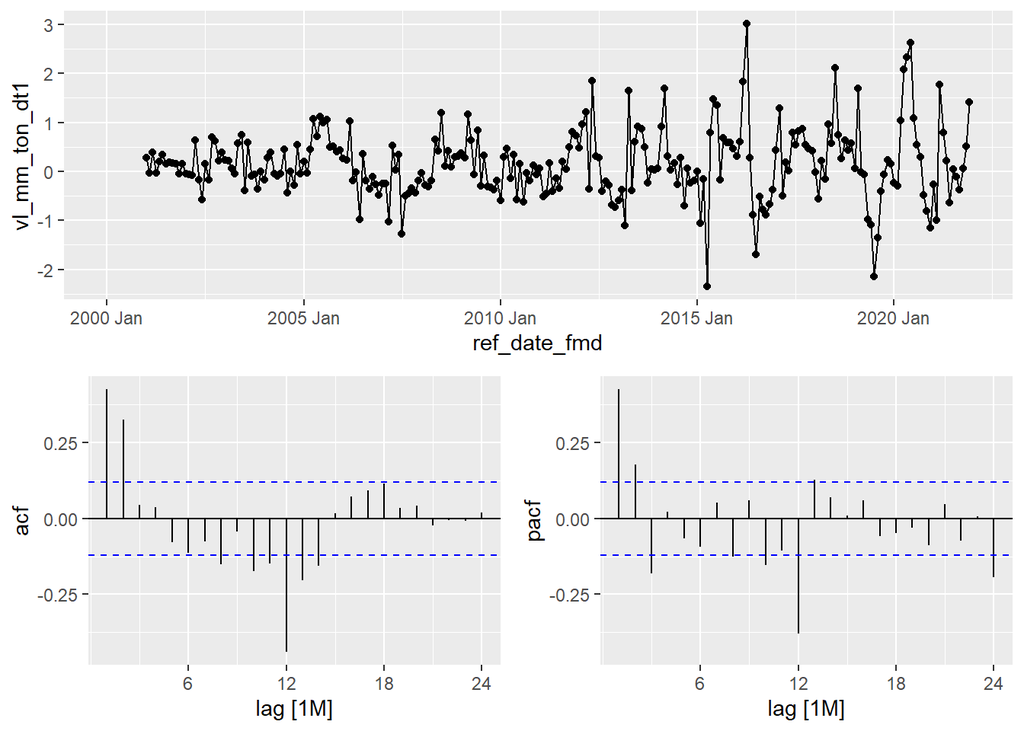

```r
## Plotting the auto-correlation function and partial auto-correlation function for the export time series with one difference
dt1_midwest_soybean_tsibble %>%
  gg_tsdisplay(vl_mm_ton_dt1, plot_type='partial')
```

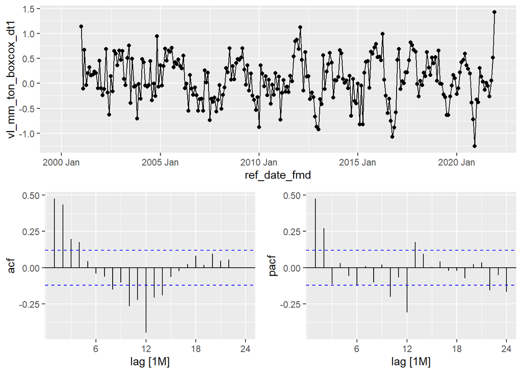

```r
## Plotting the auto-correlation function and partial auto-correlation function for the export time series with one difference
dt1_midwest_soybean_boxcox_tsibble %>%
  gg_tsdisplay(vl_mm_ton_boxcox_dt1, plot_type='partial')
```

The **ACF** and **PACF** plots for both series, applied one difference, look similar with some particularities. Looking at the **PACF** plots for the original data, it is noticeable that the remaining series shows an auto-correlation at lag 12 suggesting a **seasonal AR(1)** and a **AR(3)** model due to the high-correlation for lags lower or equal to 3. On the other hand, the **ACF** plot of the original data suggests a **seasonal MA(1)** model due to the high correlation at lag 12 and a **MA(2)** model due to the correlation for lags lower or equal to 2. Looking now at the transformed time series, the only difference is that the orders of the AR and MA models are **AR(2)** and **MA(4)**, respectively. In summary, the analysis of the **ACF / PACF** plots for both series suggests:

**Original Series**

- Candidate model 1: ARIMA(3,0,0)(1,1,0)[12]
- Candidate model 2: ARIMA(0,0,2)(1,1,0)[12]
- Candidate model 3: ARIMA(3,0,0)(0,1,1)[12]
- Candidate model 4: ARIMA(0,0,2)(0,1,1)[12]

**Transformed Series**

- Candidate model 1: ARIMA(2,0,0)(1,1,0)[12]
- Candidate model 2: ARIMA(0,0,4)(1,1,0)[12]
- Candidate model 3: ARIMA(2,0,0)(0,1,1)[12]
- Candidate model 4: ARIMA(0,0,4)(0,1,1)[12]

This models, along the models suggest by auto-arima algorithms will be verified in upcoming chapters.

## Studying seasonality

Looking at the seasonal plots bellow it becomes clear the seasonal pattern of soy bean export in the Midwest of Brazil: soy bean export are concentrated between March and July, usually peaking between March and May, whereas there is no much export between August and February. That, in fact, makes sense since soy bean is usually harvested between January and May and planted between September and December. Therefore, the peaks of soy bean production would closely related to the harvesting period of the crop. The seasonal plot bellow shows the seasonal patter for both series, original and transformed, in two different coordinate systems (Cartesian and polar) for better comprehension.

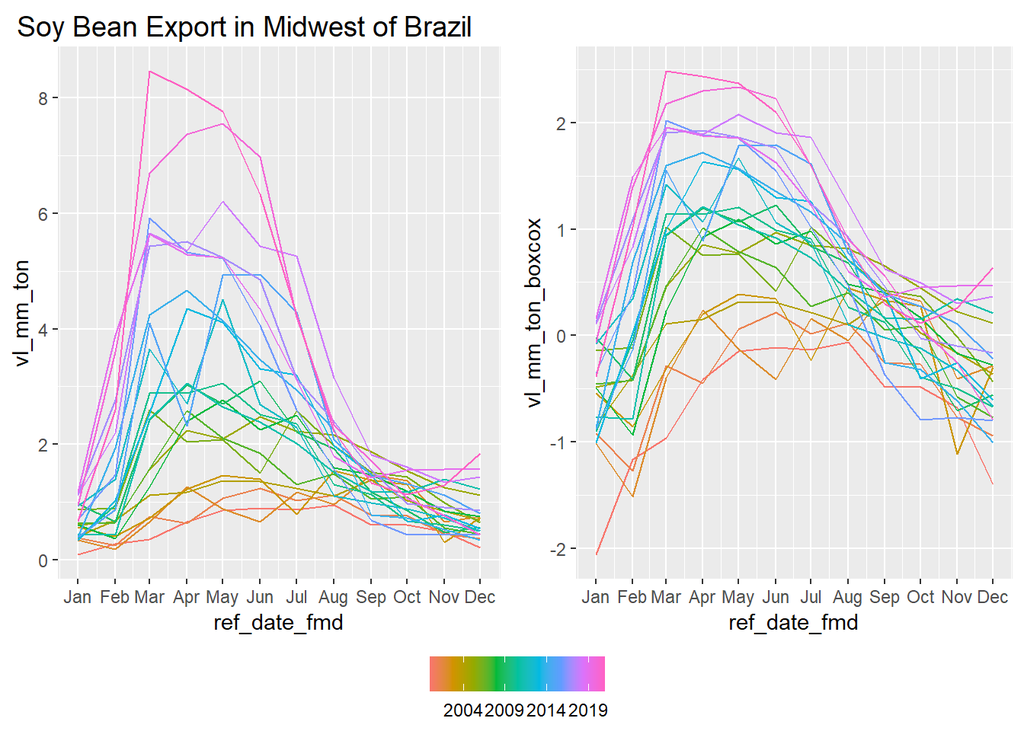

```r
## Plotting monthly seasonal chart using library feasts | Original | Cartesian view
plot_seasonality_original <- midwest_soybean_tsibble %>%
  feasts::gg_season(y=vl_mm_ton)

## Plotting monthly seasonal chart using library feasts | Transformed | Cartesian view
plot_seasonality_boxcox <- midwest_soybean_boxcox_tsibble %>%
  feasts::gg_season(y=vl_mm_ton_boxcox)

## Comparision
plot <- ggarrange(plot_seasonality_original,
                  plot_seasonality_boxcox,
                  ncol=2,
                  nrow=1,
                  widths=c(1,1),
                  legend="bottom",
                  common.legend = T)

annotate_figure(plot, top=text_grob("Soy Bean Export in Midwest of Brazil",
                                    color="#000000",
                                    size=14,
                                    x=unit(0.5, "lines"),
                                    y=unit(0, "lines"),
                                    just="left",
                                    hjust=0,
                                    vjust=0))
```

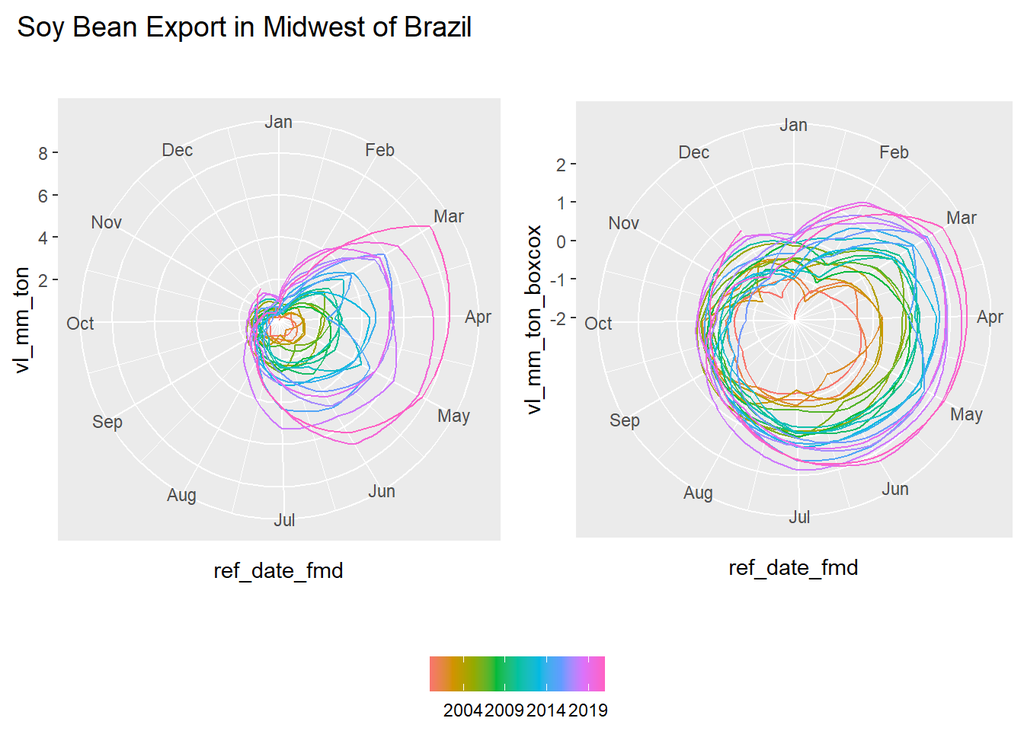

```r
## Plotting monthly seasonal chart using library feasts | Original | Polar view
plot_seasonality_original <- midwest_soybean_tsibble %>%
  feasts::gg_season(y=vl_mm_ton, polar=TRUE)

## Plotting monthly seasonal chart using library feasts | Trasnformed | Polar view
plot_seasonality_boxcox <- midwest_soybean_boxcox_tsibble %>%
  feasts::gg_season(y=vl_mm_ton_boxcox, polar=TRUE)

## Comparision
plot <- ggarrange(plot_seasonality_original,
                  plot_seasonality_boxcox,
                  ncol=2,
                  nrow=1,
                  widths=c(1,1),
                  legend="bottom",
                  common.legend = T)

annotate_figure(plot, top=text_grob("Soy Bean Export in Midwest of Brazil",
                                    color="#000000",
                                    size=14,
                                    x=unit(0.5, "lines"),
                                    y=unit(0, "lines"),
                                    just="left",
                                    hjust=0,
                                    vjust=0))
```

The plots bellow show the decomposition of the time series in its components (trend, seasonal, random), using the **ts** function from base R, considering a multiplicative model. The reason for choosing a multiplicative model at this point was made by intuition since it would be expected that the actual values of soy bean export would the result of some trend multiplied by the percentage of the crop that is export (within a year) each month and that every year, that percentage would be similar. However, the appropriate approach would be to test the two models (additive and multiplicative) and compare the performance. Comparing the plot for the two time series one thing that comes into attention is that the seasonal and random components are very different. The seasonal component of the transformed series shows a significant peak for July whereas the seasonal component of the original series shows a pattern with values more evenly distributed between months. For the purpose of this study, only the decomposition function from base R will be studied. However, other decomposition models may give a better result for understanding the components of time series, for example **STL** and **ETS** models.

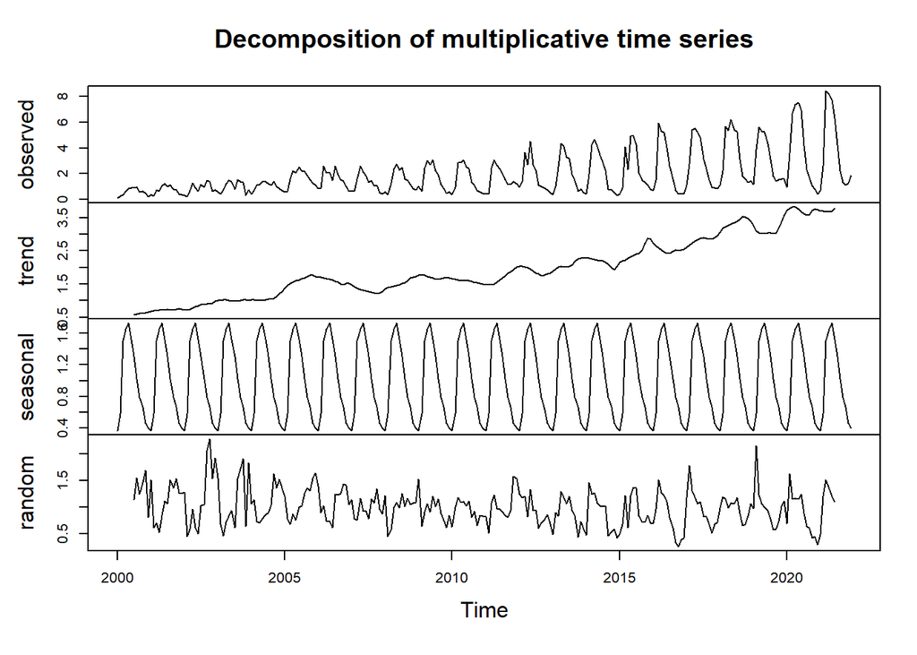

```r
## Converting the time series into a time series (ts) object
ts_midwest_soybean <- ts(data=midwest_soybean$vl_mm_ton, # selecting serie
                         start=c(2000, 1), # start month
                         end=c(2021, 12), # end month
                         frequency=12 # considering monthly frequency
                         )

## Decomposing using base R
plot(decompose(ts_midwest_soybean, "multiplicative"))
```

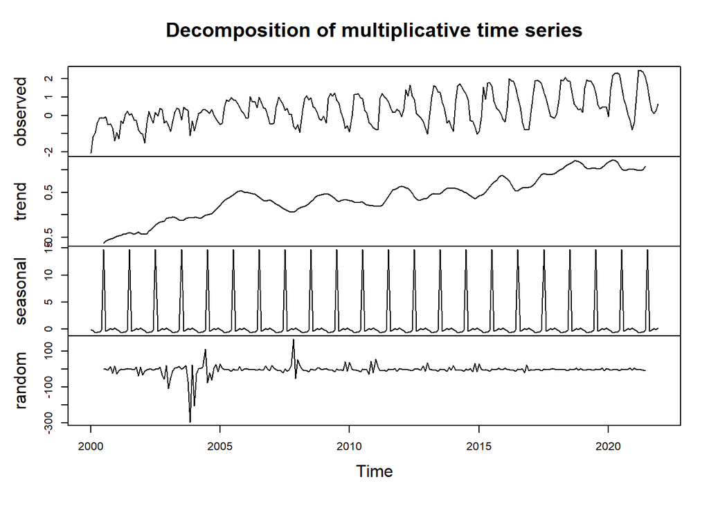

```r
## Converting the time series into a time series (ts) object
ts_midwest_soybean_boxcox <- ts(data=midwest_soybean_boxcox$vl_mm_ton_boxcox, # selecting serie
                                start=c(2000, 1), # start month
                                end=c(2021, 12), # end month
                                frequency=12 # considering monthly frequency
                                )

## Decomposing using base R
plot(decompose(ts_midwest_soybean_boxcox, "multiplicative"))
```

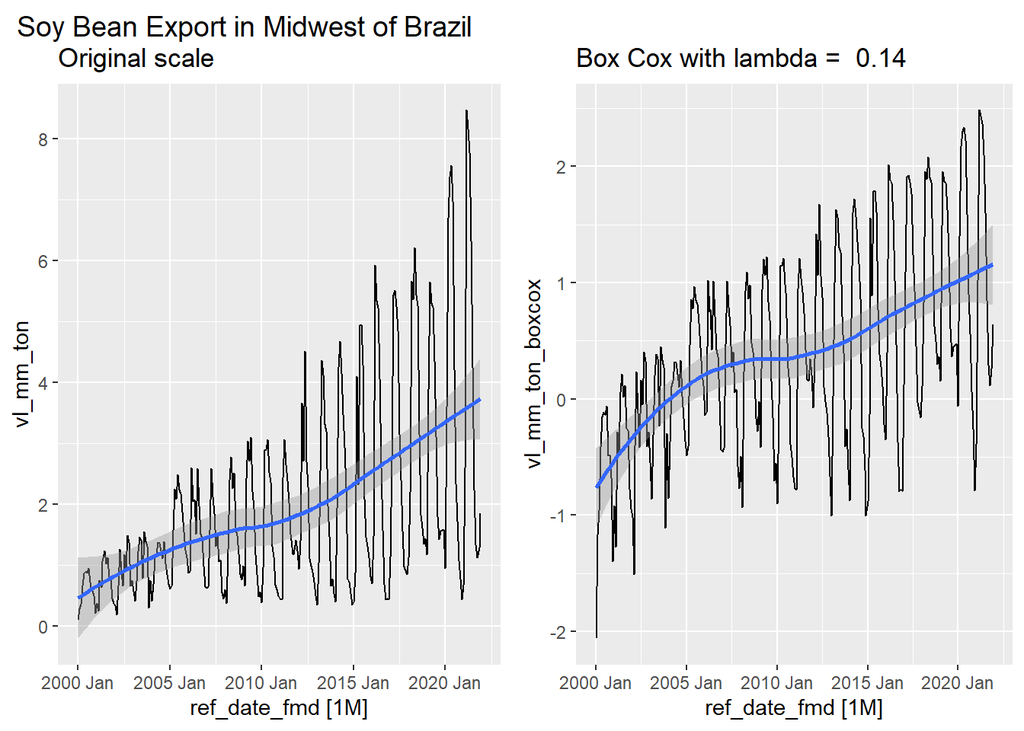

```r
## Original dataset
plot_original <- midwest_soybean_tsibble %>%
  autoplot(vl_mm_ton) +
  geom_smooth() +
  ggtitle("Original scale")

## Transformed dataset
plot_boxcox <- midwest_soybean_boxcox_tsibble %>%
  autoplot(vl_mm_ton_boxcox) +
  geom_smooth() +
  ggtitle(paste("Box Cox with lambda = ", round(attributes(boxcox_transform)$lambda,2)))

## Comparision
plot <- ggarrange(plot_original, plot_boxcox, ncol=2, nrow=1, widths=c(1,1), common.legend = FALSE)

annotate_figure(plot, top=text_grob("Soy Bean Export in Midwest of Brazil",
                                    color="#000000",
                                    size=14,
                                    x=unit(0.5, "lines"),
                                    y=unit(0, "lines"),
                                    just="left",
                                    hjust=0,
                                    vjust=0))
```

## Modeling the time series using SARIMA models

```r
## Creating a table for holding results
sarima_models <- tibble(model=as.character(), lambda=as.numeric(), aicc=as.numeric())

## Original Series

## Configuring a SARIMA model of orders: ARIMA(3,0,0)(1,1,0)[12]
fit1 <- Arima(y=ts_midwest_soybean,order=c(3,0,0),seasonal=list(order=c(1,1,0),period=12),method="ML")
sarima_models <- bind_rows(sarima_models, tibble(model="SARIMA(3,0,0)(1,1,0)[12]", lambda=NA, aicc=fit1$aicc))

## Configuring a SARIMA model of orders: ARIMA(0,0,2)(1,1,0)[12]
fit2 <- Arima(y=ts_midwest_soybean,order=c(0,0,2),seasonal=list(order=c(1,1,0),period=12),method="ML")
sarima_models <- bind_rows(sarima_models, tibble(model="SARIMA(0,0,2)(1,1,0)[12]", lambda=NA, aicc=fit2$aicc))

## Configuring a SARIMA model of orders: ARIMA(3,0,0)(0,1,1)[12]
fit3 <- Arima(y=ts_midwest_soybean,order=c(3,0,0),seasonal=list(order=c(0,1,1),period=12),method="ML")
sarima_models <- bind_rows(sarima_models, tibble(model="SARIMA(3,0,0)(0,1,1)[12]", lambda=NA, aicc=fit3$aicc))

## Configuring a SARIMA model of orders: ARIMA(0,0,2)(0,1,1)[12]
fit4 <- Arima(y=ts_midwest_soybean,order=c(0,0,2),seasonal=list(order=c(0,1,1),period=12),method="ML")
sarima_models <- bind_rows(sarima_models, tibble(model="SARIMA(0,0,2)(0,1,1)[12]", lambda=NA, aicc=fit4$aicc))

## Additional model to be tested
## Configuring a SARIMA model of orders: ARIMA(2,0,0)(2,1,2)[12]
fit5 <- Arima(y=ts_midwest_soybean,order=c(2,0,0),seasonal=list(order=c(2,1,2),period=12),method="ML")
sarima_models <- bind_rows(sarima_models, tibble(model="SARIMA(2,0,0)(2,1,2)[12]", lambda=NA, aicc=fit5$aicc))

##Using auto.arima
## Configuring a SARIMA model using auto-arima using setpwise algorithm
fit6 <- auto.arima(y=ts_midwest_soybean, stepwise = T)
sarima_models <- bind_rows(sarima_models, tibble(model="Stepwise: SARIMA(0,0,2)(1,1,2)[12]", lambda=NA, aicc=fit6$aicc))

## Configuring a SARIMA model using auto-arima using setpwise algorithm
fit7 <- auto.arima(y=ts_midwest_soybean, stepwise = F)
sarima_models <- bind_rows(sarima_models, tibble(model="Search: SARIMA(0,0,2)(1,1,2)[12]", lambda=NA, aicc=fit7$aicc))


## Box-Cox Transformed Series

## Configuring a SARIMA model of orders: ARIMA(2,0,0)(1,1,0)[12]
fit8 <- Arima(y=ts_midwest_soybean,order=c(2,0,0),seasonal=list(order=c(1,1,0),period=12),method="ML",lambda=boxcox_lambda)
sarima_models <- bind_rows(sarima_models, tibble(model="SARIMA(2,0,0)(1,1,0)[12]", lambda=fit8$lambda[1], aicc=fit8$aicc))

## Configuring a SARIMA model of orders: ARIMA(0,0,4)(1,1,0)[12]
fit9 <- Arima(y=ts_midwest_soybean,order=c(0,0,4),seasonal=list(order=c(1,1,0),period=12),method="ML",lambda=boxcox_lambda)
sarima_models <- bind_rows(sarima_models, tibble(model="SARIMA(0,0,4)(1,1,0)[12]", lambda=fit9$lambda[1], aicc=fit9$aicc))

## Configuring a SARIMA model of orders: ARIMA(2,0,0)(0,1,1)[12]
fit10 <- Arima(y=ts_midwest_soybean,order=c(2,0,0),seasonal=list(order=c(0,1,1),period=12),method="ML",lambda=boxcox_lambda)
sarima_models <- bind_rows(sarima_models, tibble(model="SARIMA(2,0,0)(0,1,1)[12]", lambda=fit10$lambda[1], aicc=fit10$aicc))

## Configuring a SARIMA model of orders: ARIMA(0,0,4)(0,1,1)[12]
fit11 <- Arima(y=ts_midwest_soybean,order=c(0,0,4),seasonal=list(order=c(0,1,1),period=12),method="ML",lambda=boxcox_lambda)
sarima_models <- bind_rows(sarima_models, tibble(model="SARIMA(0,0,4)(0,1,1)[12]", lambda=fit11$lambda[1], aicc=fit11$aicc))

##Using auto.arima
## Configuring a SARIMA model using auto-arima using setpwise algorithm
fit12 <- auto.arima(y=ts_midwest_soybean, stepwise = T, lambda=boxcox_lambda)
sarima_models <- bind_rows(sarima_models,tibble(model="Stepwise: SARIMA(3,0,0)(0,1,1)[12]",lambda=fit12$lambda[1], aicc=fit12$aicc))

## Configuring a SARIMA model using auto-arima using setpwise algorithm
fit13 <- auto.arima(y=ts_midwest_soybean, stepwise = F, lambda=boxcox_lambda)
sarima_models <- bind_rows(sarima_models,tibble(model="Search: SARIMA(2,0,0)(2,1,1)[12]",lambda=fit13$lambda[1], aicc=fit13$aicc))

sarima_models
```

```
## # A tibble: 13 x 3
##    model                              lambda  aicc
##    <chr>                               <dbl> <dbl>
##  1 SARIMA(3,0,0)(1,1,0)[12]           NA      438.
##  2 SARIMA(0,0,2)(1,1,0)[12]           NA      441.
##  3 SARIMA(3,0,0)(0,1,1)[12]           NA      423.
##  4 SARIMA(0,0,2)(0,1,1)[12]           NA      431.
##  5 SARIMA(2,0,0)(2,1,2)[12]           NA      397.
##  6 Stepwise: SARIMA(0,0,2)(1,1,2)[12] NA      387.
##  7 Search: SARIMA(0,0,2)(1,1,2)[12]   NA      387.
##  8 SARIMA(2,0,0)(1,1,0)[12]            0.138  173.
##  9 SARIMA(0,0,4)(1,1,0)[12]            0.138  177.
## 10 SARIMA(2,0,0)(0,1,1)[12]            0.138  148.
## 11 SARIMA(0,0,4)(0,1,1)[12]            0.138  157.
## 12 Stepwise: SARIMA(3,0,0)(0,1,1)[12]  0.138  138.
## 13 Search: SARIMA(2,0,0)(2,1,1)[12]    0.138  142.
```

It can be seen that for both series the **stepwise** algorithm from **auto.arima** does a good job finding the best models due to low **AICc** values. In order to verify if the models mentioned have captured all the information available in the series, a **Ljung-Box** test is performed on the residuals of both models in order to verify if the residuals behave as white noise. If the Ljung-Box test returns a large p-value (we fail to reject the null hypothesis), also suggesting that the residuals are **white noise**. Ljung-Box hypothesis:

- H0: The residuals **behave like white noise**;
- H1: The residuals **do not behave like white noise**;

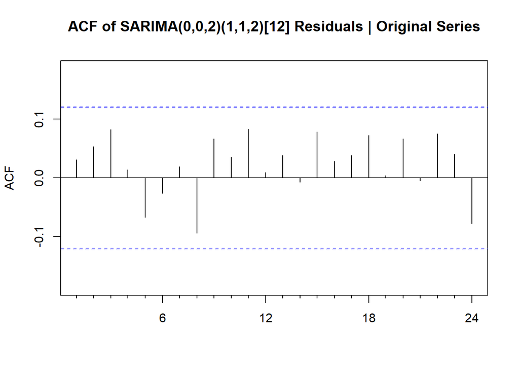

```r
## Ljung-Box test in the residuals
par(mfrow=c(1,1))
Acf(fit6$residuals, main="ACF of SARIMA(0,0,2)(1,1,2)[12] Residuals | Original Series", xlab="")
```

```r
## Ljung-Box test in the residuals
print(x=Box.test(fit6$residuals, lag=12, fitdf=1, type="Ljung-Box"))
```

```
##
##  Box-Ljung test
##
## data:  fit6$residuals
## X-squared = 10.353, df = 11, p-value = 0.4989
```

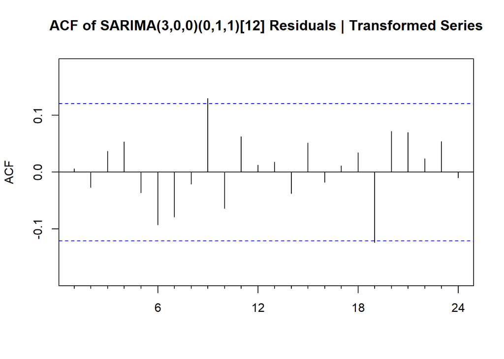

```r
## Ljung-Box test in the residuals
par(mfrow=c(1,1))
Acf(fit12$residuals, main="ACF of SARIMA(3,0,0)(0,1,1)[12] Residuals | Transformed Series", xlab="")
```

```r
## Ljung-Box test in the residuals
print(x=Box.test(fit12$residuals, lag=12, fitdf=1, type="Ljung-Box"))
```

```
##
##  Box-Ljung test
##
## data:  fit12$residuals
## X-squared = 12.706, df = 11, p-value = 0.313
```

## Plotting the forecast of the time series using the chosen SARIMA model

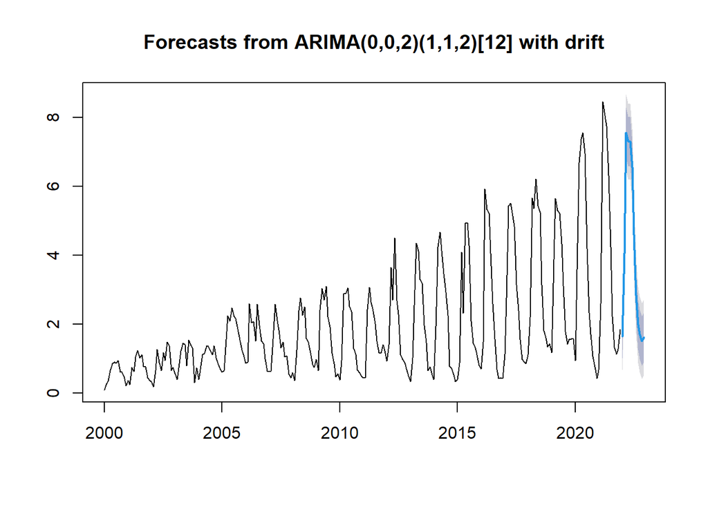

```r
## Plotting the forecast of the original time series
plot_forecast_original <- plot(forecast(fit6,h=12))
```

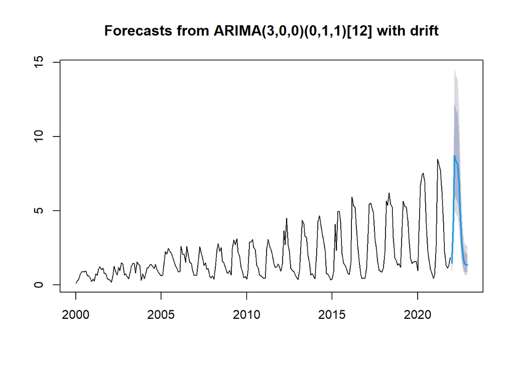

```r
## Plotting the forecast of the box-cox trnsformed time series
plot_forecast_boxcox <- plot(forecast(fit12,h=12))
```

## Backtest

```r
#197 observações (75%) para a base de treino - e 67 (25%) de observações para a base de teste
#Como estamos trabalhando com ts, primeiro ordenamos e escolhemos as primeiras 197 obs
#tr <- midwest_soybean_tsibble %>%
#          arrange(ref_date_fmd) %>%
#          head(197) %>%
#          pull(name = 'vl_mm_ton')

#Como estamos trabalhando com ts, primeiro ordenamos e escolhemos as últimas 67 obs
#teste <- midwest_soybean_tsibble %>%
#          arrange(ref_date_fmd) %>%
#          tail(67) %>%
#          pull(name = 'vl_mm_ton')
```

```r
#Geramos dois modelos a partir da base de treino
#Abaixo selecionamos o melhor modelo dos sarimas que testamos (era o modelo 1)
#fit1 = Arima(tr,order=c(2,0,0),seasonal=list(order=c(2,1,2),period=12),method="ML")

#Abaixo selecionamos o melhor modelo dos Prophet que testamos - ver com o Rodrigo)
#fit2 = Arima(tr,order=c(1,0,0),seasonal=list(order=c(1,1,0),period=12),method="ML")
```

```r
#Comparando as previsões com a base de teste
#fazemos então a previsão com o modelo sarima para os próximos 67 meses
#forecast_01 <- forecast(fit1, h = 67)
#plot(forecast_01)

#fazemos a previsão com o modelo prophet para os próxmos 67 meses
#forecast_02 <- forecast(fit2, h = 67)#aqui incluiríamos o modelo prophet
#plot(forecast_02)

#Comparamos as duas previsões com a base teste para ver qual o melhor modelo
#accuracy(forecast_01, teste)
#accuracy(forecast_02, teste)
```

### Bibliography

[1] Hyndman, R.J., & Athanasopoulos, G. (2021) Forecasting: principles and practice, 3rd edition, OTexts: Melbourne, Australia. OTexts.com/fpp3. Accessed on 2022-11-01.

[2] Indicadores Agricultura, Ministério da Agrigultura Brasileiro. https://indicadores.agricultura.gov.br/agrostat/index.htm. Acessed on 2022-10-29.

- https://harlecin.netlify.app/post/box-cox-and-other-transformations/